# Causal Examples

Simon Brewer

5/19/2023

## Libraries and whatnot

```r
library(tidyverse)
# library(broom)
library(patchwork)
library(scales)
library(dagitty)
library(ggdag)
library(latex2exp)  # Easily convert LaTeX into arcane plotmath expressions
library(ggtext)     # Use markdown in ggplot labels

# Create a cleaner serifed theme to use throughout
theme_do_calc <- function() {
  theme_dag(base_family = "Times New Roman") +
    theme(plot.title = element_text(size = rel(1.5)),
          plot.subtitle = element_markdown())
}

# Make all geom_dag_text() layers use these settings automatically
update_geom_defaults(ggdag:::GeomDagText, list(family = "Times New Roman",
                                               fontface = "bold",
                                               color = "black"))
```

## Confounders

Confounders are anything that have an open path between the input / intervention variables and the outcome

### Simple confounder

This has no causal link between `x` and `y`, and a single confounder (`z`)

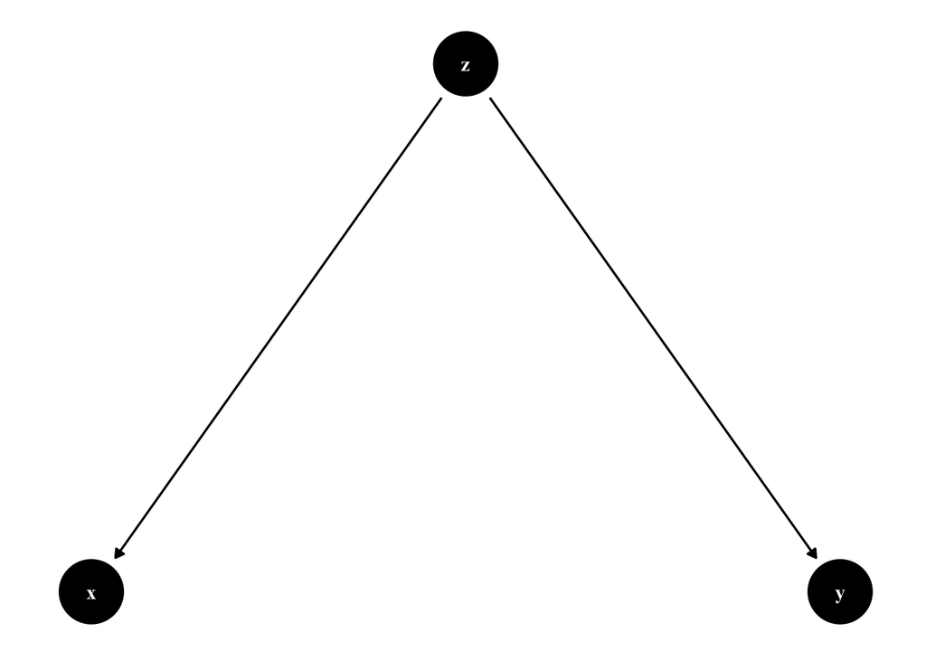

```r
confounder_dag <- dagify(x ~ z,
                         y ~ z,
                         coords = list(x = c(x = 1, y = 3, z = 2),
                                       y = c(x = 1, y = 1, z = 2)),
                         exposure = "x",
                         outcome = "y")

ggdag(confounder_dag) +
  theme_dag()
```

Independence: `x` and `y` are independent (conditioned on `z`)

```r
impliedConditionalIndependencies(confounder_dag)
```

```
## x _||_ y | z
```

Adjustment set: shows what adjustment is necessary to obtain the causal link between input and outcome

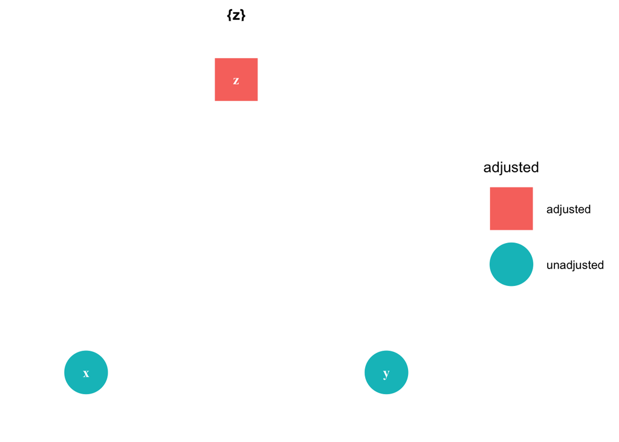

```r
ggdag_adjustment_set(confounder_dag) +
  theme_dag()
```

Simulated data - Equations

- `z`: $N(10, 5)$
- `x ~ z`: $\beta_1 = 5$
- `y ~ z`: $\beta_2 = 2$

```r
n <- 1000
z <- rnorm(n, 10, 5)
x <- z * 5 + rnorm(n, 0, 2)
y <- z * 2 + rnorm(n, 0, 2)
df <- data.frame(x, y, z)
```

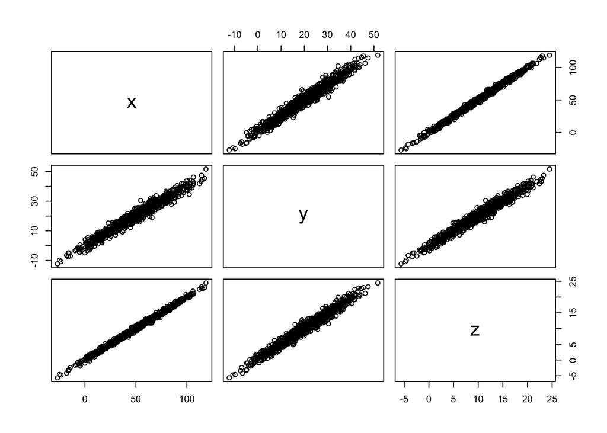

```r
pairs(df)
```

Model of `y ~ x`. Ignoring the confounder results in spurious relationship between intervention and outcome

```r
fit <- lm(y ~ x, df)
summary(fit)
```

```
##
## Call:
## lm(formula = y ~ x, data = df)
##
## Residuals:
##     Min      1Q  Median      3Q     Max
## -7.4353 -1.4519  0.0196  1.4620  8.4831
##
## Coefficients:
##             Estimate Std. Error t value Pr(>|t|)
## (Intercept) 0.060644   0.149702   0.405    0.685
## x           0.400546   0.002692 148.796   <2e-16 ***
## ---
## Signif. codes:  0 '***' 0.001 '**' 0.01 '*' 0.05 '.' 0.1 ' ' 1
##
## Residual standard error: 2.12 on 998 degrees of freedom
## Multiple R-squared:  0.9569, Adjusted R-squared:  0.9568
## F-statistic: 2.214e+04 on 1 and 998 DF,  p-value: < 2.2e-16
```

Model controlling for `z`. This removes the backdoor path between `x` and `y` and removes the apparent relationship

```r
fit <- lm(y ~ x + z, df)
summary(fit)
```

```
##
## Call:
## lm(formula = y ~ x + z, data = df)
##
## Residuals:
##     Min      1Q  Median      3Q     Max
## -6.5543 -1.3356  0.0109  1.3548  7.3978
##
## Coefficients:
##             Estimate Std. Error t value Pr(>|t|)
## (Intercept) -0.08844    0.14025  -0.631    0.528
## x            0.01916    0.03137   0.611    0.542
## z            1.91960    0.15736  12.198   <2e-16 ***
## ---
## Signif. codes:  0 '***' 0.001 '**' 0.01 '*' 0.05 '.' 0.1 ' ' 1
##
## Residual standard error: 1.979 on 997 degrees of freedom
## Multiple R-squared:  0.9625, Adjusted R-squared:  0.9624
## F-statistic: 1.278e+04 on 2 and 997 DF,  p-value: < 2.2e-16
```

### Simple confounder 2

This is the same graph as before, but now we include a real relationship between `x` and `y`

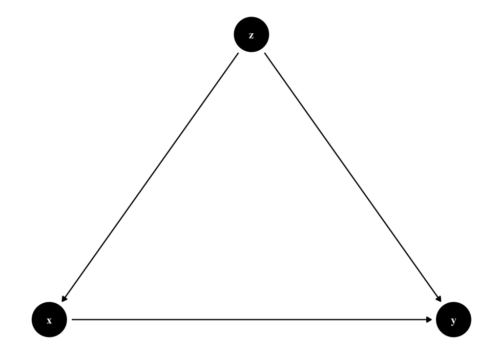

```r
confounder_dag <- dagify(x ~ z,
                         y ~ x + z,
                         coords = list(x = c(x = 1, y = 3, z = 2),
                                       y = c(x = 1, y = 1, z = 2)),
                         exposure = "x",
                         outcome = "y")

ggdag(confounder_dag) +
  theme_dag()
```

Independence: Now `x` and `y` have no conditional independence

```r
impliedConditionalIndependencies(confounder_dag)
```

Adjustment set:

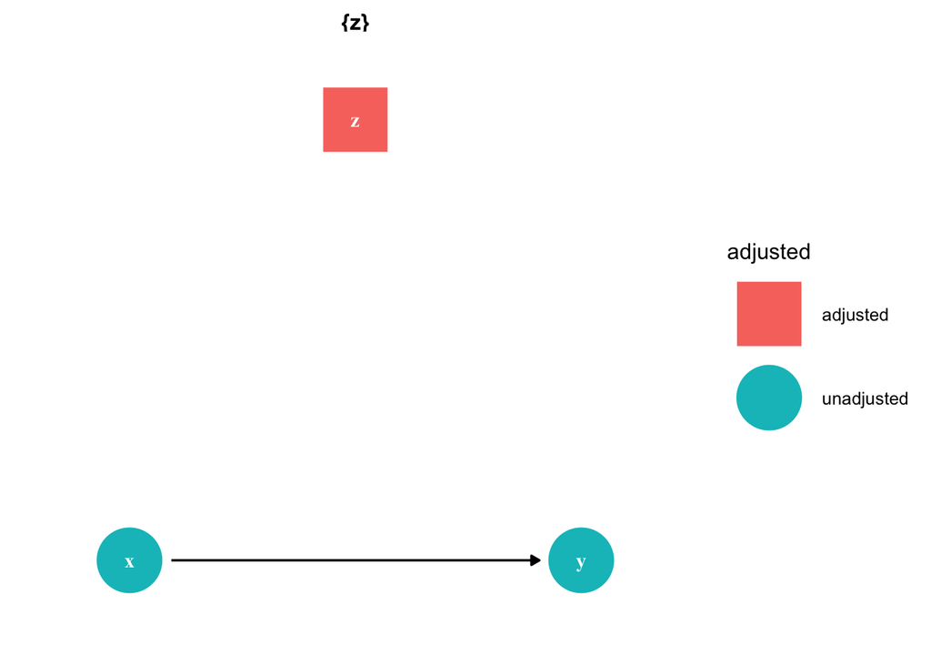

```r
ggdag_adjustment_set(confounder_dag) +
  theme_dag()
```

Equations

- `z`: $N(10, 5)$
- `x ~ z`: $\beta_1 = 5$
- `y ~ x + z`: $\beta_2 = -4$, $\beta_3 = 2$

```r
n <- 1000
z <- rnorm(n, 10, 5)
x <- z * 5 + rnorm(n, 0, 5)
y <- x * -4 + z * 2 + rnorm(n, 0, 5)
df <- data.frame(x, y, z)
```

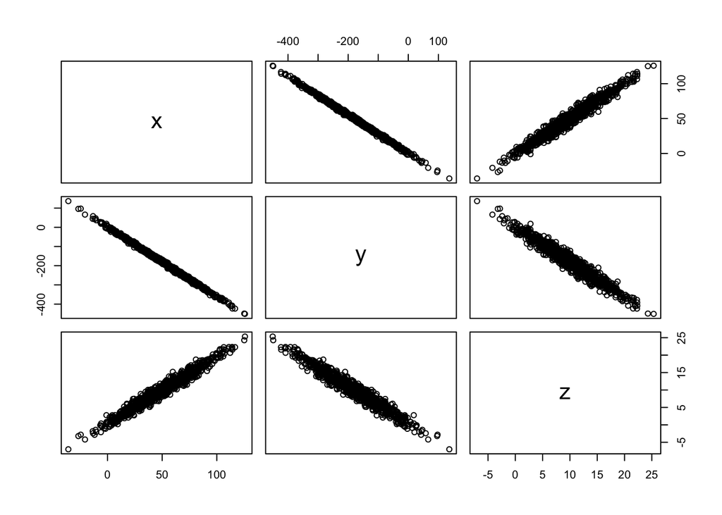

```r
pairs(df)
```

Model of `y ~ x`. Without controlling for the confounder, the coefficient relating `x` and `y` is biased (the relationship exists, but it’s biased)

```r
fit <- lm(y ~ x, df)
summary(fit)
```

```
##
## Call:
## lm(formula = y ~ x, data = df)
##
## Residuals:
##      Min       1Q   Median       3Q      Max
## -18.0418  -3.7413  -0.0501   4.1509  14.1030
##
## Coefficients:
##              Estimate Std. Error  t value Pr(>|t|)
## (Intercept)  1.030269   0.370411    2.781  0.00551 **
## x           -3.618905   0.006732 -537.566  < 2e-16 ***
## ---
## Signif. codes:  0 '***' 0.001 '**' 0.01 '*' 0.05 '.' 0.1 ' ' 1
##
## Residual standard error: 5.373 on 998 degrees of freedom
## Multiple R-squared:  0.9966, Adjusted R-squared:  0.9966
## F-statistic: 2.89e+05 on 1 and 998 DF,  p-value: < 2.2e-16
```

Model controlling for `z`. Now we get the right value for the coefficient ($\sim4$)

```r
fit <- lm(y ~ x + z, df)
summary(fit)
```

```
##
## Call:
## lm(formula = y ~ x + z, data = df)
##
## Residuals:
##      Min       1Q   Median       3Q      Max
## -15.5052  -3.3983   0.1755   3.5922  14.1267
##
## Coefficients:
##             Estimate Std. Error  t value Pr(>|t|)
## (Intercept)  0.01340    0.34903    0.038    0.969
## x           -4.03167    0.03122 -129.145   <2e-16 ***
## z            2.17202    0.16101   13.490   <2e-16 ***
## ---
## Signif. codes:  0 '***' 0.001 '**' 0.01 '*' 0.05 '.' 0.1 ' ' 1
##
## Residual standard error: 4.943 on 997 degrees of freedom
## Multiple R-squared:  0.9971, Adjusted R-squared:  0.9971
## F-statistic: 1.708e+05 on 2 and 997 DF,  p-value: < 2.2e-16
```

### Two variable confounder

This is to illustrate Pearl’s point about uncessary confounders. This graph has a backdoor path with two confounding variables (`z1` and `z2`). In order to test a causal link between `x` and `y`, we *only* need to control for one, as either will block the back door path

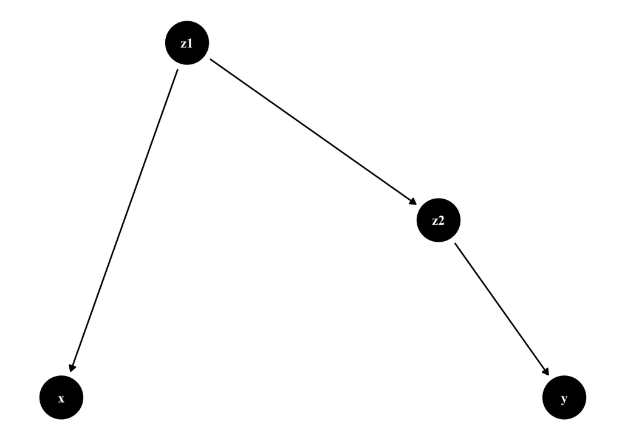

```r
confounder_dag <- dagify(x ~ z1,
                         z2 ~ z1,
                         y ~ z2,
                         coords = list(x = c(x = 1, y = 3, z1 = 1.5, z2 = 2.5),
                                       y = c(x = 1, y = 1, z1 = 2, z2 = 1.5)),
                         exposure = "x",
                         outcome = "y")

ggdag(confounder_dag) +
  theme_dag()
```

Independence:

```r
impliedConditionalIndependencies(confounder_dag)
```

```
## x _||_ y | z2
## x _||_ y | z1
## x _||_ z2 | z1
## y _||_ z1 | z2
```

Adjustment set: Now we get two adjustment sets, as controlling for either `z1` or `z2` removes the path

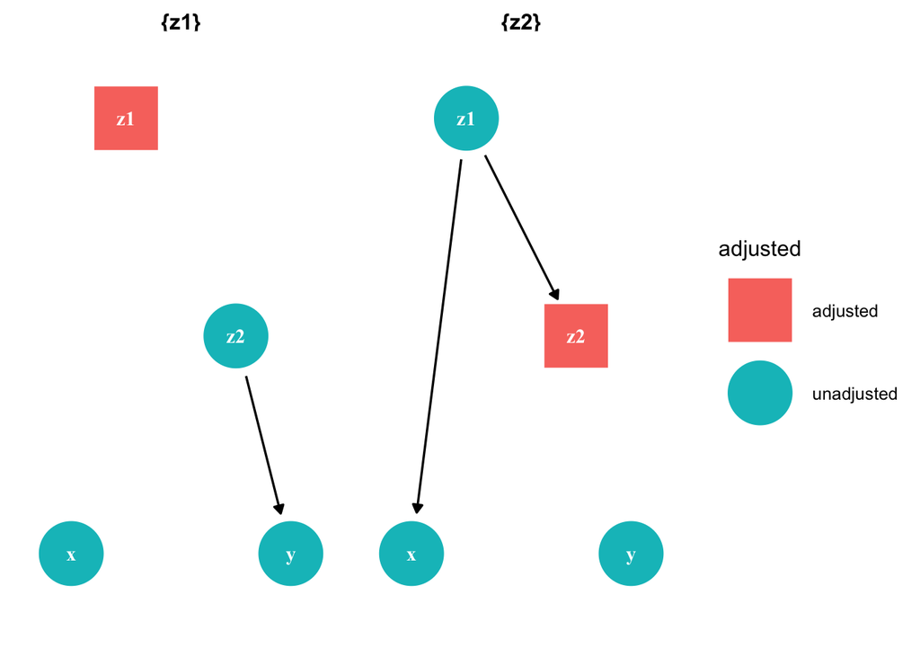

```r
ggdag_adjustment_set(confounder_dag) +
  theme_dag()
```

Equations

- `z1`: $N(10, 5)$
- `x ~ z1`: $\beta_1 = 5$
- `y ~ z2`: $\beta_2 = 2$
- `z2 ~ z1`: $beta_3 = -4$

```r
n <- 1000
z1 <- rnorm(n, 10, 5)
x <- z1 * 5 + rnorm(n, 0, 5)
z2 <- z1 * -4 + rnorm(n, 0, 5)
y <- z2 * 2 + rnorm(n, 0, 5)
df <- data.frame(x, y, z1, z2)
```

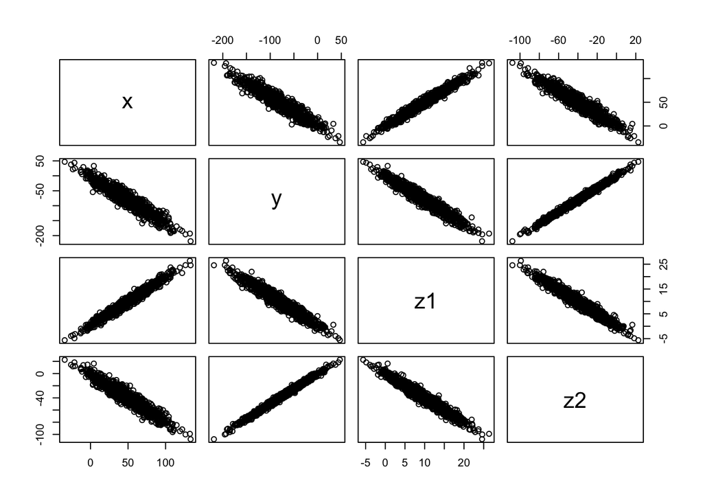

```r
pairs(df)
```

Model of `y ~ x` (shows spurious relationship)

```r
fit <- lm(y ~ x, df)
summary(fit)
```

```
##
## Call:
## lm(formula = y ~ x, data = df)
##
## Residuals:
##     Min      1Q  Median      3Q     Max
## -49.794  -9.120  -0.193   9.542  44.221
##
## Coefficients:
##             Estimate Std. Error t value Pr(>|t|)
## (Intercept) -4.28403    0.92604  -4.626 4.21e-06 ***
## x           -1.52431    0.01681 -90.671  < 2e-16 ***
## ---
## Signif. codes:  0 '***' 0.001 '**' 0.01 '*' 0.05 '.' 0.1 ' ' 1
##
## Residual standard error: 13.79 on 998 degrees of freedom
## Multiple R-squared:  0.8917, Adjusted R-squared:  0.8916
## F-statistic:  8221 on 1 and 998 DF,  p-value: < 2.2e-16
```

Control for `z1`

```r
fit1 <- lm(y ~ x + z1, df)
summary(fit1)
```

```
##
## Call:
## lm(formula = y ~ x + z1, data = df)
##
## Residuals:
##     Min      1Q  Median      3Q     Max
## -34.874  -7.352  -0.076   7.590  38.858
##
## Coefficients:
##             Estimate Std. Error t value Pr(>|t|)
## (Intercept) -1.17410    0.75458  -1.556    0.120
## x            0.08298    0.06963   1.192    0.234
## z1          -8.34251    0.35456 -23.529   <2e-16 ***
## ---
## Signif. codes:  0 '***' 0.001 '**' 0.01 '*' 0.05 '.' 0.1 ' ' 1
##
## Residual standard error: 11.07 on 997 degrees of freedom
## Multiple R-squared:  0.9304, Adjusted R-squared:  0.9303
## F-statistic:  6664 on 2 and 997 DF,  p-value: < 2.2e-16
```

Control for `z2`

```r
fit2 <- lm(y ~ x + z2, df)
summary(fit2)
```

```
##
## Call:
## lm(formula = y ~ x + z2, data = df)
##
## Residuals:
##      Min       1Q   Median       3Q      Max
## -17.3395  -3.5788   0.0877   3.3608  16.5777
##
## Coefficients:
##             Estimate Std. Error t value Pr(>|t|)
## (Intercept) -0.35927    0.34042  -1.055    0.292
## x           -0.01003    0.01970  -0.509    0.611
## z2           1.98457    0.02454  80.878   <2e-16 ***
## ---
## Signif. codes:  0 '***' 0.001 '**' 0.01 '*' 0.05 '.' 0.1 ' ' 1
##
## Residual standard error: 5.019 on 997 degrees of freedom
## Multiple R-squared:  0.9857, Adjusted R-squared:  0.9857
## F-statistic: 3.432e+04 on 2 and 997 DF,  p-value: < 2.2e-16
```

Control for both (this works, but is more costly in regression terms)

```r
fit3 <- lm(y ~ x + z1 + z2, df)
summary(fit3)
```

```
##
## Call:
## lm(formula = y ~ x + z1 + z2, data = df)
##
## Residuals:
##      Min       1Q   Median       3Q      Max
## -17.3375  -3.5836   0.0897   3.3596  16.5768
##
## Coefficients:
##              Estimate Std. Error t value Pr(>|t|)
## (Intercept) -0.358095   0.342662  -1.045    0.296
## x           -0.009253   0.031631  -0.293    0.770
## z1          -0.006553   0.209650  -0.031    0.975
## z2           1.983932   0.031991  62.015   <2e-16 ***
## ---
## Signif. codes:  0 '***' 0.001 '**' 0.01 '*' 0.05 '.' 0.1 ' ' 1
##
## Residual standard error: 5.021 on 996 degrees of freedom
## Multiple R-squared:  0.9857, Adjusted R-squared:  0.9856
## F-statistic: 2.286e+04 on 3 and 996 DF,  p-value: < 2.2e-16
```

**REDO THIS WITH A LINK**

## Collider

This is the second type of path junction that can cause problems. Here, our two variables (`x` and `y`) are independent, but are both linked to `z`, the collider. Ths issue with this relationship is the bias that results *when we control for the collider*

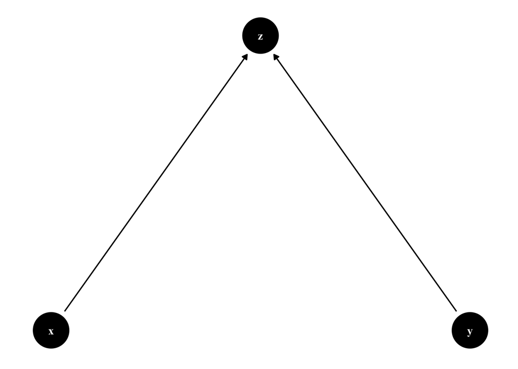

```r
collider_dag <- dagify(z ~ x,
                       z ~ y,
                       coords = list(x = c(x = 1, y = 3, z = 2),
                                     y = c(x = 1, y = 1, z = 2)),
                         exposure = "x",
                         outcome = "y")

ggdag(collider_dag) +
  theme_dag()
```

Independence: In the case, there is no conditional independence. `x` and `y` are unconditionally independent

```r
impliedConditionalIndependencies(collider_dag)
```

```
## x _||_ y
```

Adjustment set: now we do not need to adjust our model

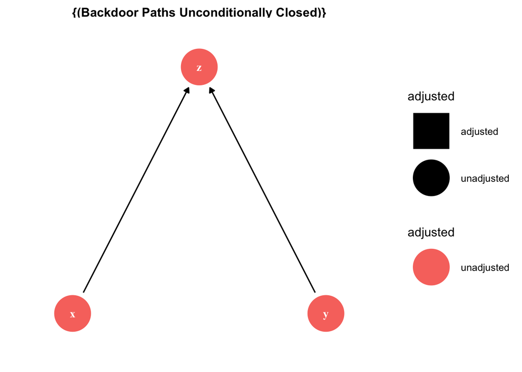

```r
ggdag_adjustment_set(collider_dag) +
  theme_dag()
```

Separation: This is a test for $d$-separation in a DAG. $d$-separation indicates that two variables are independent

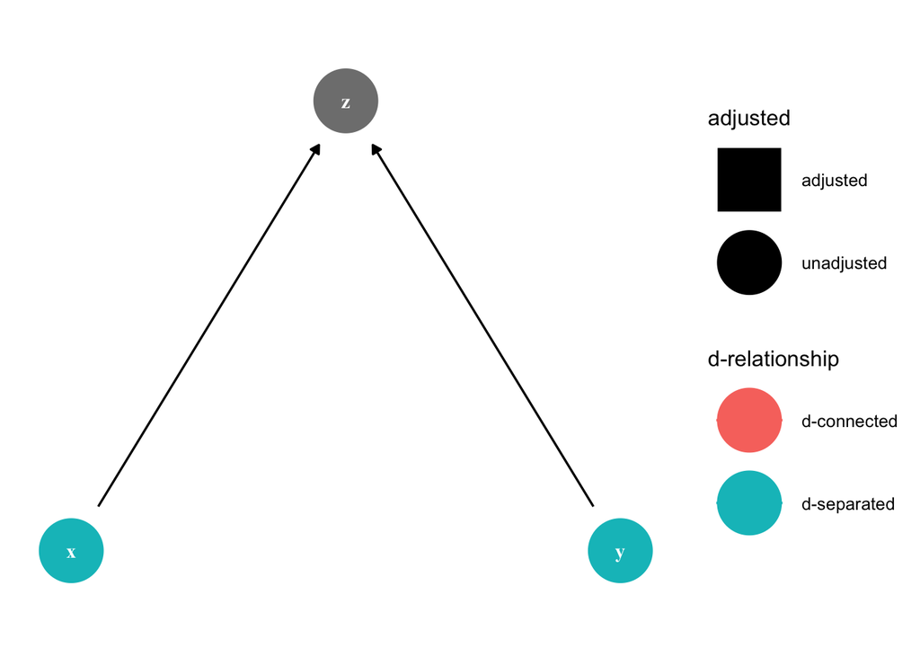

```r
ggdag_dseparated(collider_dag) +
  theme_dag()
```

We can also test for $d$-separation when we control for `z`. THis now shows that a backdoor path has been opened by the control, resulting in a spurious link between `x` and `y` (**MAYBE ADD DSEP TO CONFOUNDER EXAMPLES?**)

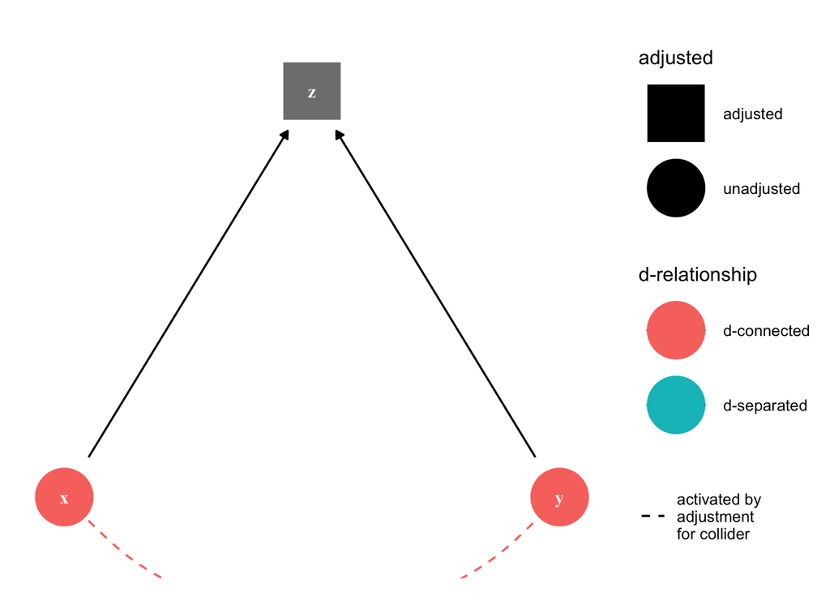

```r
ggdag_dseparated(collider_dag, controlling_for = "z") +
  theme_dag()
```

Equations

- `x`: $N(10, 2)$
- `y`: $N(5, 1)$
- `z ~ x + y`: $\beta_1 = 5$, $\beta_2 = 2$

```r
n <- 1000
x <- rnorm(n, 10, 2)
y <- rnorm(n, 5, 1)
z <- 5 * x + 2 * y + rnorm(n, 0, 2)
df <- data.frame(x, y, z)
```

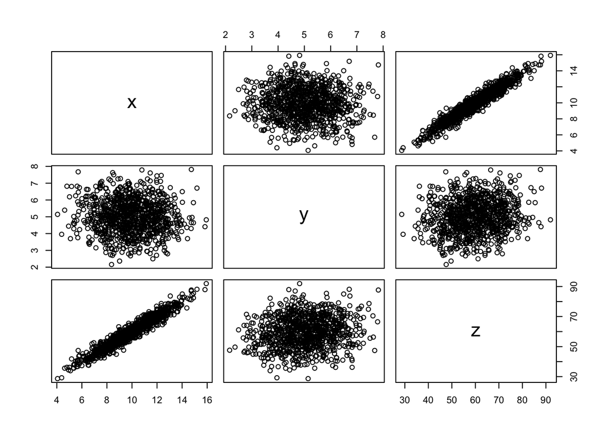

```r
pairs(df)
```

Model of `y ~ x` - this returns the unbiased link (or lack thereof) between `x` and `y` given the collider

```r
fit <- lm(y ~ x, df)
summary(fit)
```

```
##
## Call:
## lm(formula = y ~ x, data = df)
##
## Residuals:
##      Min       1Q   Median       3Q      Max
## -2.89594 -0.67048 -0.00892  0.68538  2.91451
##
## Coefficients:
##             Estimate Std. Error t value Pr(>|t|)
## (Intercept)  5.24637    0.16025  32.739   <2e-16 ***
## x           -0.02326    0.01584  -1.469    0.142
## ---
## Signif. codes:  0 '***' 0.001 '**' 0.01 '*' 0.05 '.' 0.1 ' ' 1
##
## Residual standard error: 0.9919 on 998 degrees of freedom
## Multiple R-squared:  0.002157,   Adjusted R-squared:  0.001157
## F-statistic: 2.157 on 1 and 998 DF,  p-value: 0.1422
```

Model controlling for `z`. This now results in a spurious relationship between `x` and `y`

```r
fit <- lm(y ~ x + z, df)
summary(fit)
```

```
##
## Call:
## lm(formula = y ~ x + z, data = df)
##
## Residuals:
##     Min      1Q  Median      3Q     Max
## -2.1190 -0.4944 -0.0144  0.4856  2.1635
##
## Coefficients:
##              Estimate Std. Error t value Pr(>|t|)
## (Intercept)  2.655394   0.145238   18.28   <2e-16 ***
## x           -1.243600   0.042452  -29.29   <2e-16 ***
## z            0.246427   0.008251   29.86   <2e-16 ***
## ---
## Signif. codes:  0 '***' 0.001 '**' 0.01 '*' 0.05 '.' 0.1 ' ' 1
##
## Residual standard error: 0.721 on 997 degrees of freedom
## Multiple R-squared:  0.4733, Adjusted R-squared:  0.4723
## F-statistic:   448 on 2 and 997 DF,  p-value: < 2.2e-16
```

**REPEAT WITH LINK BETWEEN X AND Y**